# Who Does More Pushups

Holden Katin-Bayer

Fall 2026

# Introduction

Data R from George Town College Football Team. Question is, is there a difference in the number of push ups that can be done in two minutes, between players on the line position and players in the skill positions.

$H_0$ : There is no difference between the number of push ups that can be done in two minutes between line and skill positions.

$H_A$ : There is a difference between the number of push ups that can be done in two minutes between line and skill positions.

# Methods

Position is a categorical variable , a number of push ups is a numerical variable. Number of push ups is described by position so we use the numerical~CAT helper file.

# Results

## Descriptive Results

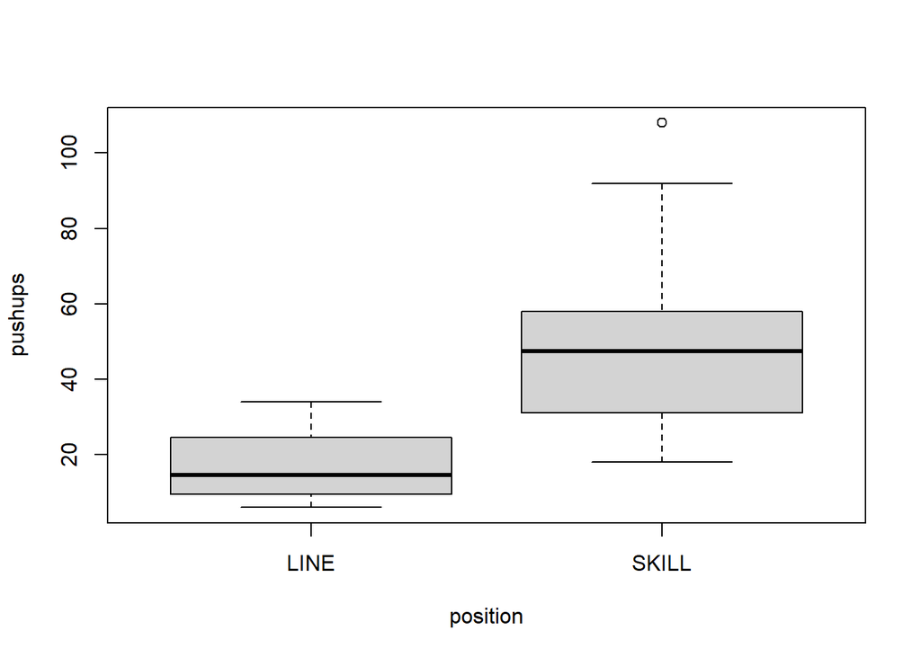

```r
boxplot(pushups~position,data=pushups)
```

This box plot shows that skill position did more push ups in two minutes than line position.

### Graphical Descriptive Results

### Numerical Descriptive Results

```r
favstats(pushups~position,data=pushups)
```

```
##   position min    Q1 median    Q3 max     mean        sd  n missing
## 1     LINE   6 10.25   14.5 24.25  34 17.12500  9.745878  8       0
## 2    SKILL  18 31.25   47.5 57.50 108 49.72727 23.036579 22       0
```

The numerical summary shows the skill position players on average did about 3x as many push ups in two minutes than did line players.

## Inferential Results

```r
t.test(pushups~position,data=pushups)
```

```
##
##  Welch Two Sample t-test
##
## data:  pushups by position
## t = -5.4341, df = 27.079, p-value = 9.421e-06
## alternative hypothesis: true difference in means between group LINE and group SKILL is not equal to 0
## 95 percent confidence interval:
##  -44.91068 -20.29387
## sample estimates:
##  mean in group LINE mean in group SKILL
##            17.12500            49.72727
```

The p value is 0.00000942, this is less than .05 so we reject the null hypothesis and conclude that players on the skill position on average can do more push ups in two minutes than players on the line position.

# Discussion and Conclusion

Based on the t test comparing the means between skill and line players, there is a difference between the number of push ups able to be completed in two minutes, and skill position players can on average complete more push ups than line.